# Notebook

### Web Information Retrieval and Data Mining - Assignment 3

```
Student: REVACLIER, ARTHUR (0980598)
```

#### Answer 1.1, Baseline (4p)

- Dense network, at least 3 layers, shaped like a pyramid
  - Last layer: 10 nodes, sigmoid.
  - Loss: categorical cross-entropy. Metric: accuracy
- No preprocessing, regularization. Get at least 70% accuracy.
- Explain design decisions. Discuss performance.
  - Does it overfit (large/growing gap between loss and val_loss)?

[output not shown]

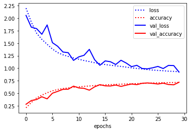

```
Model: "sequential_87"
_________________________________________________________________
Layer (type)                 Output Shape              Param #
=================================================================
reshape_86 (Reshape)         (None, 3072)              0
_________________________________________________________________
dense_306 (Dense)            (None, 49)                150577
_________________________________________________________________
dense_307 (Dense)            (None, 31)                1550
_________________________________________________________________
dense_308 (Dense)            (None, 23)                736
_________________________________________________________________
dense_309 (Dense)            (None, 10)                240
=================================================================
Total params: 153,103
Trainable params: 153,103
Non-trainable params: 0
_________________________________________________________________
None
def build_model_1_1():
    model = models.Sequential()
    model.add(layers.Reshape((3072,), input_shape=(32,32,3)))
    model.add(layers.Dense(49, activation='relu'))
    model.add(layers.Dense(31, activation='relu'))
    model.add(layers.Dense(23, activation='relu'))
    model.add(layers.Dense(10, activation='softmax'))
    model.compile(optimizer='rmsprop',
                  loss='categorical_crossentropy',
                  metrics=['accuracy'])
    return model
```

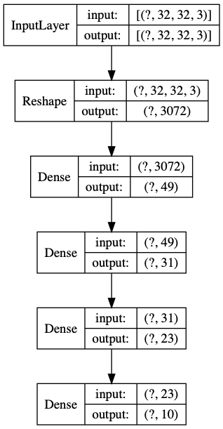

#### Answer 1.2, Preprocess (2p)

- Convert images to greyscale, other preprocessing optional.
  - Input shape should be (32,32,1)
- Explain design decisions. Is it better? Why (not)?
  - Color information is likely not so useful for classification. Greyscale makes the network smaller, less parameters to learn, less likely to overfit.

[output not shown]

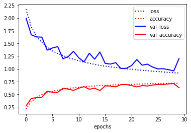

```
Model: "sequential_17"
_________________________________________________________________
Layer (type)                 Output Shape              Param #
=================================================================
reshape_17 (Reshape)         (None, 1024)              0
_________________________________________________________________
dense_68 (Dense)             (None, 49)                50225
_________________________________________________________________
dense_69 (Dense)             (None, 31)                1550
_________________________________________________________________
dense_70 (Dense)             (None, 23)                736
_________________________________________________________________
dense_71 (Dense)             (None, 10)                240
=================================================================
Total params: 52,751
Trainable params: 52,751
Non-trainable params: 0
_________________________________________________________________
None
def build_model_1_2():
    model = models.Sequential()
    model.add(layers.Reshape((1024,), input_shape=(32,32,1,)))
    model.add(layers.Dense(49, activation='relu'))
    model.add(layers.Dense(31, activation='relu'))
    model.add(layers.Dense(23, activation='relu'))
    model.add(layers.Dense(10, activation='softmax'))
    model.compile(optimizer='rmsprop',
                  loss='categorical_crossentropy',
                  metrics=['accuracy'])
    return model
```

#### Answer 1.3, Tune (4p)

- Regularize the model. What works best?
  - Should consider batch normalization, dropout, l1/l2 regularization (or Nesterov)
- Tune other hyperparameters (e.g. learning rate, batch size,...) as you see fit.
  - At least consider tuning learning rate, ideally also momentum, decay, other optimizers
- Explain your findings and final design decisions. Discuss the results.
  - Should be better, at least it shouldn't overfit

[output not shown]

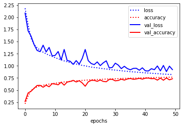

```
def build_model_1_3():
    model = models.Sequential()
    model.add(layers.Reshape((1024,), input_shape=(32,32,1,)))
    model.add(layers.Dense(49, activation='relu', kernel_regularizer=regularizers.l2(0.0001), bias_regularizer=regularizers.l1(0.001)))
    model.add(layers.Dense(31, activation='relu', kernel_regularizer=regularizers.l2(0.0001), bias_regularizer=regularizers.l1(0.001)))
    model.add(layers.Dense(23, activation='relu', kernel_regularizer=regularizers.l2(0.0001), bias_regularizer=regularizers.l1(0.001)))
    model.add(layers.Dense(10, activation='softmax'))

    opti = optimizers.RMSprop(lr=0.0005)
    model.compile(loss='categorical_crossentropy',
                  metrics=['accuracy'],
                  optimizer=opti)
    return model
```

#### Answer 2.1, ConvNet (7p)

- Build a sequential ConvNet, get at least 90% accuracy.
  - Conv2D layers, input shape (32,32,1)
  - Consider using blocks of Conv2D layers with maxpooling in between
  - Use zero-padding in Conv2D layers because the images are small
  - At least one dense hidden layer and dense output layer (sigmoid)
  - Consider adding batch normalization, dropout
  - Consider small dropout rates in beginning, larger dropout rates later in network
  - Consider other optimizers and tuning learning rate, momentum,...
- Explain what you did and why (800 chars). Is it working well?
  - Should be quite elaborate and sensible

[output not shown]

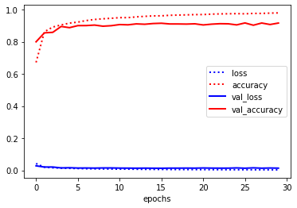

```
Model: "sequential_3"
_________________________________________________________________
Layer (type)                 Output Shape              Param #
=================================================================
conv2d (Conv2D)              (None, 30, 30, 32)        320
_________________________________________________________________
leaky_re_lu (LeakyReLU)      (None, 30, 30, 32)        0
_________________________________________________________________
batch_normalization (BatchNo (None, 30, 30, 32)        128
_________________________________________________________________
max_pooling2d (MaxPooling2D) (None, 15, 15, 32)        0
_________________________________________________________________
conv2d_1 (Conv2D)            (None, 15, 15, 32)        9248
_________________________________________________________________
leaky_re_lu_1 (LeakyReLU)    (None, 15, 15, 32)        0
_________________________________________________________________
batch_normalization_1 (Batch (None, 15, 15, 32)        128
_________________________________________________________________
max_pooling2d_1 (MaxPooling2 (None, 8, 8, 32)          0
_________________________________________________________________
conv2d_2 (Conv2D)            (None, 8, 8, 64)          18496
_________________________________________________________________
leaky_re_lu_2 (LeakyReLU)    (None, 8, 8, 64)          0
_________________________________________________________________
batch_normalization_2 (Batch (None, 8, 8, 64)          256
_________________________________________________________________
max_pooling2d_2 (MaxPooling2 (None, 4, 4, 64)          0
_________________________________________________________________
conv2d_3 (Conv2D)            (None, 4, 4, 64)          36928
_________________________________________________________________
leaky_re_lu_3 (LeakyReLU)    (None, 4, 4, 64)          0
_________________________________________________________________
batch_normalization_3 (Batch (None, 4, 4, 64)          256
_________________________________________________________________
max_pooling2d_3 (MaxPooling2 (None, 2, 2, 64)          0
_________________________________________________________________
conv2d_4 (Conv2D)            (None, 2, 2, 128)         73856
_________________________________________________________________
leaky_re_lu_4 (LeakyReLU)    (None, 2, 2, 128)         0
_________________________________________________________________
```

[output cut: 57 more lines]

```

    model.add(layers.Conv2D(128, (3, 3), activation='relu', padding='same'))
    model.add(layers.LeakyReLU(0.1))
    model.add(layers.BatchNormalization())
    model.add(layers.MaxPooling2D(pool_size=(2, 2), padding='same'))

    model.add(layers.Flatten())
    model.add(layers.Dense(32))
    model.add(layers.LeakyReLU(0.1))
    model.add(layers.Dropout(0.2))
    model.add(layers.Dense(10, activation='softmax'))

    model.compile(optimizer = 'adam', loss = 'mse', metrics=['accuracy'])

    return model
```

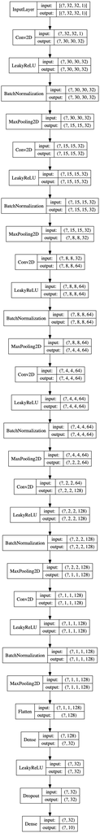

#### Answer 2.2, Data Augmentation (3p)

- Augment the preprocessed training data.
  - Use small variations (small shifts up-down, left-right) of flips becasue the images are small
  - Large shifts and rotations distort the image too much
- Explain what you did and why. Discuss the performance of the model.

```
I tried each proposed transformation. In every case, I achieved a lesser result accuracy wise regarding the validation dataset. The highest validation accuracy I achieved was with the parameters left here, and it is still 4% worse than the model running without augmenting the data.  (length: 284)

Max val score: 87.64%
```

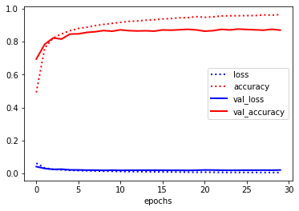

```
    datagen = ImageDataGenerator(
        width_shift_range=0.2,
        height_shift_range=0.3,
        shear_range=0.4,
        zoom_range=[1.0, 1.6],
        samplewise_center=True,
        samplewise_std_normalization=True
    )
```

#### Answer 3.1, Misclassifications (2p)

[output not shown]

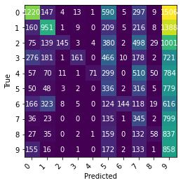

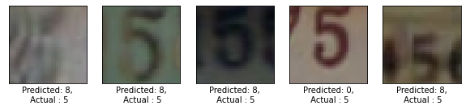

#### Answer 3.2, Activations (4p)

- Retrieve and visualize the activations for one example
- For every filter for different convolutional layers (at different depths in the network).
- Give an explanation. Is your model indeed learning something useful?
  - Should detect edges etc in first layers, higher-order object (e.g. interesting regions) in deeper layers.

```
We mostly observe how the model recognizes the 8 on the first layer. Layer 5 is already not providing much information and the deeper the model goes, the less information is gained until it doesn't learn anything on the last layer.  (length: 233)
```

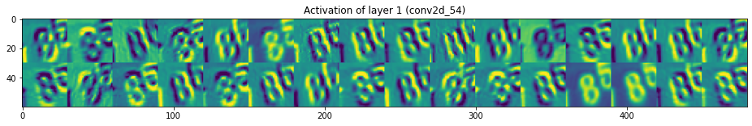

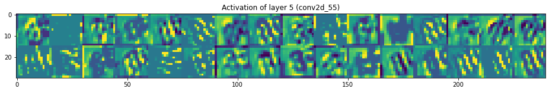

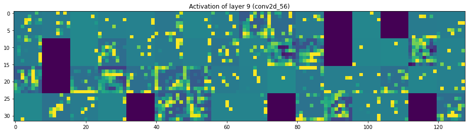

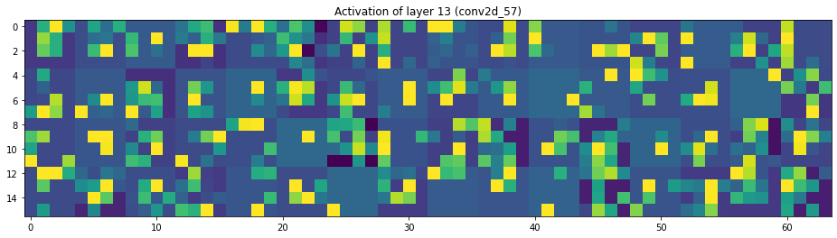

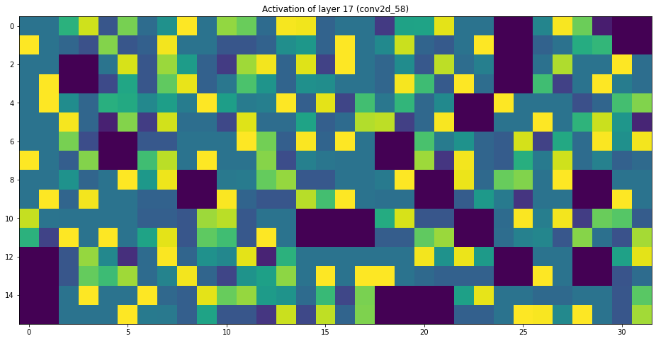

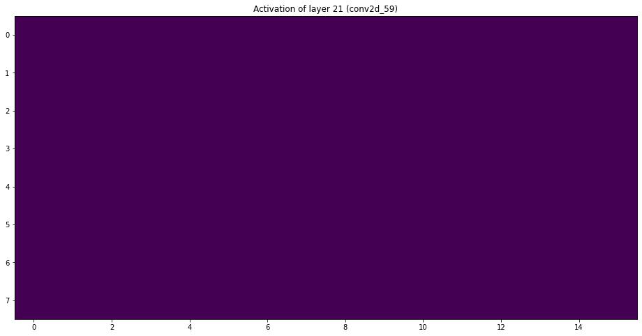

#### Answer 3.3, Class activation map (4p)

- Show a class activation map for your last convolutional layer
- Superimpose the activation map over the image, or plot side by side
  - Should make sense, detect interesting regions to classify the number

[output not shown]

#### Answer 4.1, Fast feature extraction (5p)

- Import the VGG16 model, pretrained on ImageNet
- Freeze convolutional base, adds a dense layer
- Consider unfreezing the last few convolutional layers and evaluate whether that works better
  - Check if they do. It is very likely to help.
- Discuss the observed performance
  - Should get around 80% accuracy

[output not shown]

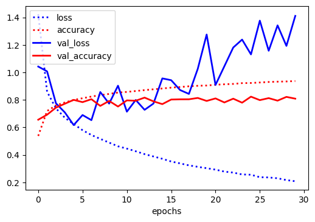

```
Model: "sequential_18"
_________________________________________________________________
Layer (type)                 Output Shape              Param #
=================================================================
vgg16 (Model)                (None, 1, 1, 512)         14714688
_________________________________________________________________
flatten_12 (Flatten)         (None, 512)               0
_________________________________________________________________
dense_31 (Dense)             (None, 10)                5130
=================================================================
Total params: 14,719,818
Trainable params: 7,084,554
Non-trainable params: 7,635,264
_________________________________________________________________
None
def build_model_4_1():
    model = models.Sequential()
    vgg_model = VGG16(include_top=False, weights='imagenet', input_shape=(32,32,3,))

    # Freeze layers
    for layer in vgg_model.layers:
        if "block5" not in layer.name:
            layer.trainable = False

    # Add VGG16
    model.add(vgg_model)
    # Add dense layer
    model.add(layers.Flatten())
    model.add(layers.Dense(10, activation='softmax'))

    model.compile(loss='categorical_crossentropy',
                  metrics=['accuracy'],
                  optimizer='rmsprop')
    return model
```

#### Answer 4.2, Embeddings (5p)

- Generate embeddings with the trained convolutional part of model_4_1 (without the dense layer)
- Embed the training and test data and store them to disk
- Build and evaluate a pipeline on the embedded data
  - Check if pipeline makes sense (e.g. use models that can handle many dimensions)
- Describe what you did and what you observed (max 800 chars).
  - Consider different models, preprocessing, tuning, etc.
  - Check performance (see original Submission.html) when in doubt. We did not run all the evaluations because it takes too long, and the output is ill-defined.

[output not shown]

```
Running time: 56.30 seconds
Last modified: May 26, 2020
scikit-learn version: 0.23.1
```